# Super projet BTC-NLP

```r
library(lubridate)
library(tidyverse)
```

# Principes généraux

Le but de l’exercice est d’essayer de prédire l’évolution du cours du Bitcoin.

- Ici, on se concentrera uniquement sur la variable binaire “Est-ce que le bitcoin a monté ou a baissé entre deux journées” ?
- On ne se souciera donc pas de *quantifier* la prédiction de hausse ou de baisse du bitcoin.

Pour cela, plusieurs idées possibles :

- Utiliser les données Google Trends pour voir un peu les tendances haussières / baissières
- Faire du NLP sur les forums de Bitcoin (sentiment analysis ?)
- Essayer de faire une analyse technique financière d’après le Bitcoin

# Retrieve the Bitcoin data

For information, the file `bitcoin_price.csv` has been downloaded from Coindesk ([available here](https://www.coindesk.com/price/)).

```r
bitcoin.data = read.csv("./data/bitcoin_price.csv")
```

## Cleaning the data a bit

```r
bitcoin.data = bitcoin.data %>% filter(!is.na(Close.Price)) # Remove the last two lines
```

```r
bitcoin.data$Date = bitcoin.data$Date %>% # Remove the time from the date
  sapply(as.character) %>%
  sapply(substr, 1, 10)
bitcoin.data$Date = ymd(bitcoin.data$Date) # Transform the date from string into a lubridate
```

## Generate the binary variable we need to predict

```r
binary.variable = rep(NA, nrow(bitcoin.data) - 1)
for(i in c(1:(nrow(bitcoin.data) - 1))){

  if(bitcoin.data$Close.Price[i] > bitcoin.data$Close.Price[i+1]){

    binary.variable[i] = "Down"

  } else {binary.variable[i] = "Up"}

}
bitcoin.data = bitcoin.data %>% filter(Date != ymd("2015-12-31"))
```

```r
bitcoin.data$Trend = binary.variable
```

## Result: data that is clean, with the proper variable to predict

| Date | Close.Price | Trend |
| --- | --- | --- |
| 2016-01-01 | 434.46 | Up |
| 2016-01-02 | 433.59 | Down |
| 2016-01-03 | 430.36 | Down |
| 2016-01-04 | 433.49 | Up |
| 2016-01-05 | 432.25 | Down |
| 2016-01-06 | 429.46 | Down |
| 2016-01-07 | 458.28 | Up |
| 2016-01-08 | 453.37 | Down |
| 2016-01-09 | 449.14 | Down |
| 2016-01-10 | 448.96 | Down |

[output cut: 983 more lines]

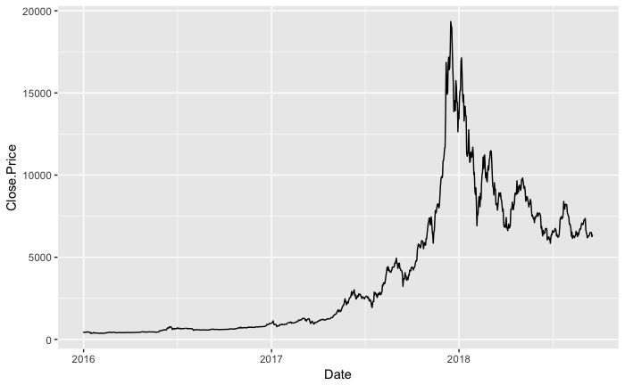

```r
ggplot(data = bitcoin.data,
       aes(x = Date, y = Close.Price)) +
  geom_line()
```

# Données regroupées

```r
NLP_data = read.csv('./data/NLP_grouped_data.csv')
NLP_data
```

| date | polarity | log_merit | post | polarity_and_log_merit |
| --- | --- | --- | --- | --- |
| 2016-01-02 | 0.12349947 | 5.203897 | 102 | 0.7101897 |
| 2016-01-03 | 0.12134777 | 5.826353 | 39 | 0.7054949 |
| 2016-01-04 | 0.09309665 | 4.806805 | 50 | 0.3860475 |
| 2016-01-05 | 0.12109117 | 6.209135 | 59 | 0.7590357 |
| 2016-01-06 | 0.11571384 | 5.715966 | 73 | 0.6406449 |
| 2016-01-07 | 0.13126411 | 5.834435 | 70 | 0.7640733 |
| 2016-01-08 | 0.08655992 | 5.501565 | 35 | 0.5169724 |
| 2016-01-09 | 0.13656764 | 6.468401 | 25 | 0.8887305 |
| 2016-01-10 | 0.21692893 | 6.091068 | 45 | 1.3271311 |
| 2016-01-11 | 0.15250861 | 6.024359 | 56 | 0.9113638 |

[output cut: 976 more lines]

## Reformater la date

```r
NLP_data$date = NLP_data$date %>% # Remove the time from the date
  sapply(as.character)
NLP_data$date = ymd(NLP_data$date)
NLP_data
```

| date | polarity | log_merit | post | polarity_and_log_merit |
| --- | --- | --- | --- | --- |
| 2016-01-02 | 0.12349947 | 5.203897 | 102 | 0.7101897 |
| 2016-01-03 | 0.12134777 | 5.826353 | 39 | 0.7054949 |
| 2016-01-04 | 0.09309665 | 4.806805 | 50 | 0.3860475 |
| 2016-01-05 | 0.12109117 | 6.209135 | 59 | 0.7590357 |
| 2016-01-06 | 0.11571384 | 5.715966 | 73 | 0.6406449 |
| 2016-01-07 | 0.13126411 | 5.834435 | 70 | 0.7640733 |
| 2016-01-08 | 0.08655992 | 5.501565 | 35 | 0.5169724 |
| 2016-01-09 | 0.13656764 | 6.468401 | 25 | 0.8887305 |
| 2016-01-10 | 0.21692893 | 6.091068 | 45 | 1.3271311 |
| 2016-01-11 | 0.15250861 | 6.024359 | 56 | 0.9113638 |

[output cut: 976 more lines]

## Join

```r
full_data = inner_join(NLP_data, bitcoin.data)
full_data$trend = as.factor(full_data$trend)
```

## Split by training and testing data

```r
train_data = full_data %>% filter(date < ymd('2017/01/05') | date > ymd('2018/01/05'))
test_data = full_data %>% filter(date >= ymd('2017/01/05') & date <= ymd('2018/01/05'))
```

## Dummy classifier

```r
max(sum(test_data$trend == "Up"), sum(test_data$trend == "Down")) / nrow(test_data)
```

```
[1] 0.6038251
```

## Logistic regression

```r
reg.model = glm(trend ~ date + polarity + log_merit + post + polarity_and_log_merit, family = "binomial", data = train_data)
summary(reg.model)
```

```
Call:
glm(formula = trend ~ date + polarity + log_merit + post + polarity_and_log_merit,
    family = "binomial", data = train_data)

Deviance Residuals:
   Min      1Q  Median      3Q     Max
-1.390  -1.269   1.004   1.066   1.413

Coefficients:
                         Estimate Std. Error z value Pr(>|z|)
(Intercept)            -1.446e+01  1.532e+01  -0.944   0.3454
date                    8.643e-04  8.454e-04   1.022   0.3066
polarity                1.506e+00  1.062e+01   0.142   0.8873
log_merit               3.752e-02  3.312e-01   0.113   0.9098
post                   -4.843e-04  2.378e-04  -2.036   0.0417 *
polarity_and_log_merit -3.268e-01  1.894e+00  -0.173   0.8630
---
Signif. codes:  0 ‘***’ 0.001 ‘**’ 0.01 ‘*’ 0.05 ‘.’ 0.1 ‘ ’ 1

(Dispersion parameter for binomial family taken to be 1)

    Null deviance: 853.29  on 619  degrees of freedom
Residual deviance: 845.60  on 614  degrees of freedom
AIC: 857.6

Number of Fisher Scoring iterations: 4
```

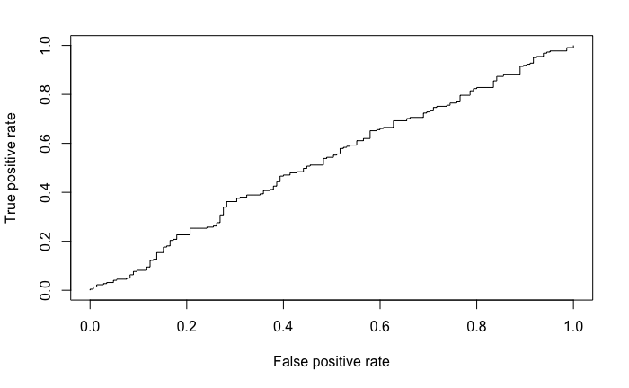

```r
reg.predict = predict(reg.model, test_data, type = "response")
reg.prediction = prediction(reg.predict, test_data$trend)
reg.perf = performance(reg.prediction, measure = "tpr", x.measure = "fpr")
plot(reg.perf)
```

```r
reg.auc = performance(reg.prediction, measure = "auc")
reg.auc = reg.auc@y.values[[1]]
reg.auc
```

```
[1] 0.5277578
```

```r
prediction_vector = rep(NA, nrow(test_data))
prediction_vector[predict(reg.model, test_data, type = "response") > 0.5] = "Up"
prediction_vector[is.na(prediction_vector)] = "Down"
sum(prediction_vector == test_data$trend) / nrow(test_data)
```

```
[1] 0.5628415
```

## Random Forest

```r
set.seed(0)
rf.model = randomForest(trend ~ date + polarity + log_merit + post + polarity_and_log_merit, data = train_data)
```

```r
sum(predict(rf.model, test_data, type = "response") == test_data$trend) / nrow(test_data)
```

```
[1] 0.6120219
```

# Quelques réflexions sur des pistes à suivre

## Analyse technique sur le cours

Pas facile à implémenter, d’autant plus que je pense qu’une des suppositoins, c’est que nos prédictions sont indépendantes (i.e. la prédiction pour le jour j doit être indépendante de celle pour le jour j+1 ou celle pour le jour j-1).

A voir si on a le droit d’utiliser les données “déjà passées” pour faire des prédictions futures (i.e. si on veut faire une prédiction pour le 10 mai, est-ce qu’on a le droit d’utiliser le cours du 1 au 9 mai ?)

## Google Trends

Piste intéressante. Mais problème : à partir d’un certain stade, les données Google Trends s’obtiennent par semaine, et plus par jour, donc on n’a plus grand chose d’exploitable.

```r
trends = read.csv('./data/trends.csv')
trends$date = ymd(trends$date)
```

### Graphe correspondant (exemple Bitcoin)

```r
ggplot(data = trends,
       aes(x = date, y = cryptocurrency)) +
  geom_line()
```

[output not shown]

# Modélisation

```r
library(ROCR)
library(randomForest)
```

## On réunit les datasets pour former un truc complet

```r
trend.data = data.frame(trends, "bitcoin.value" = bitcoin.data$Close.Price, "bitcoin.trend" = bitcoin.data$Trend)
trend.data
```

### Split entre training et test dataset

```r
set.seed(0)
train.sample = c(1:nrow(trend.data)) %in% sample(c(1:nrow(trend.data)), as.integer(nrow(trend.data) * 0.8))
train.trend = trend.data[train.sample,]
test.trend = trend.data[!train.sample,]
```

## Quelle précision de base ?

```r
max(sum(test.trend$bitcoin.trend == "Up"), sum(test.trend$bitcoin.trend == "Down")) / nrow(test.trend)
```

[output not shown]

La précision du dummy model (qui prédit toujours la même chose) sera donc de $51.3\%$.

## Premier modèle tout con : régression logistique

```r
reg.model = glm(bitcoin.trend ~ date + bitcoin + btc + hodl + blockchain, family = binomial, data = train.trend)
```

```r
reg.predict = predict(reg.model, test.trend, type = "response")
reg.prediction = prediction(reg.predict, test.trend$bitcoin.trend)
reg.perf = performance(reg.prediction, measure = "tpr", x.measure = "fpr")
plot(reg.perf)
```

[output not shown]

```r
reg.auc = performance(reg.prediction, measure = "auc")
reg.auc = reg.auc@y.values[[1]]
reg.auc
```

[output not shown]

## Autre type de modèle : Random forest

```r
set.seed(0)
rf.model = randomForest(bitcoin.trend ~ date + bitcoin + btc + hodl + blockchain, mtry = 3, data = train.trend)
```

```r
sum(predict(rf.model, test.trend, type = "response") == test.trend$bitcoin.trend) / nrow(test.trend)
```

[output not shown]